# MachineLeaningWriteup

Wei-Cheng Yang

2014年10月24日

Report points:

### data processing: load data

```r
suppressPackageStartupMessages(library(caret))
suppressPackageStartupMessages(library(e1071))
suppressPackageStartupMessages(library(plyr))
suppressPackageStartupMessages(library(dplyr))
train<-tbl_df(read.csv(file = "pml-training.csv"))
test<-tbl_df(read.csv(file = "pml-testing.csv"))
```

### data processing: clean up training set

from exploratory analysis we know there are many na’s and missing data. we can see these are because the kurtosis,skewness,max and min and summary,..are only available at a regular time interval, our target is to predict the action type and these summary values from a regular time interval are not available so we remove them from the crude database. remove all variables with missing value (which are summary figures over a time interval) remove also timestamp and timewindow for they are not correlated with the activity but only time.

We also remove 10% of the dataset for final estimation for out of sample error.

```r
has_na<-numeric(length = 160)
for (val in 1:160)
has_na[val]<-sum(is.na(train[val]))
col_index<-which(has_na==0)
train1<-train[col_index]
train_clean<-train1[-c(12:20,43:48,52:60,74:82)]
train_clean<-train_clean[-c(1:7)]

set.seed(12345)
for_oos<-createDataPartition(train_clean$classe,p = 0.1,list = FALSE)
oos<-train_clean[for_oos,]
train_final<-train_clean[-for_oos,]
```

## Building up the model and cross validation

```r
set.seed(12345)
modfit<-train(classe~.,method="gbm",data=train_final)
```

## Summary about the model we built up

```r
modfit
```

```
## Stochastic Gradient Boosting
##
## 17658 samples
##    52 predictor
##     5 classes: 'A', 'B', 'C', 'D', 'E'
##
## No pre-processing
## Resampling: Bootstrapped (25 reps)
##
## Summary of sample sizes: 17658, 17658, 17658, 17658, 17658, 17658, ...
##
## Resampling results across tuning parameters:
##
##   interaction.depth  n.trees  Accuracy  Kappa  Accuracy SD  Kappa SD
##   1                   50      0.7       0.7    0.009        0.012
##   1                  100      0.8       0.8    0.006        0.008
##   1                  150      0.9       0.8    0.005        0.007
##   2                   50      0.9       0.8    0.005        0.007
##   2                  100      0.9       0.9    0.005        0.006
##   2                  150      0.9       0.9    0.004        0.005
##   3                   50      0.9       0.9    0.004        0.005
##   3                  100      0.9       0.9    0.003        0.004
##   3                  150      1.0       0.9    0.002        0.003
##
## Tuning parameter 'shrinkage' was held constant at a value of 0.1
## Accuracy was used to select the optimal model using  the largest value.
## The final values used for the model were n.trees = 150,
##  interaction.depth = 3 and shrinkage = 0.1.
```

We can see from the result that the final model we picked has highes Accuracy ,( measures calculated from repeated cross validating 25 times by bootstrapping). The kappa statistics for measurement of agreement of prediction: kappa is 0.947, which is quite high. (>0.8 considered good fit)

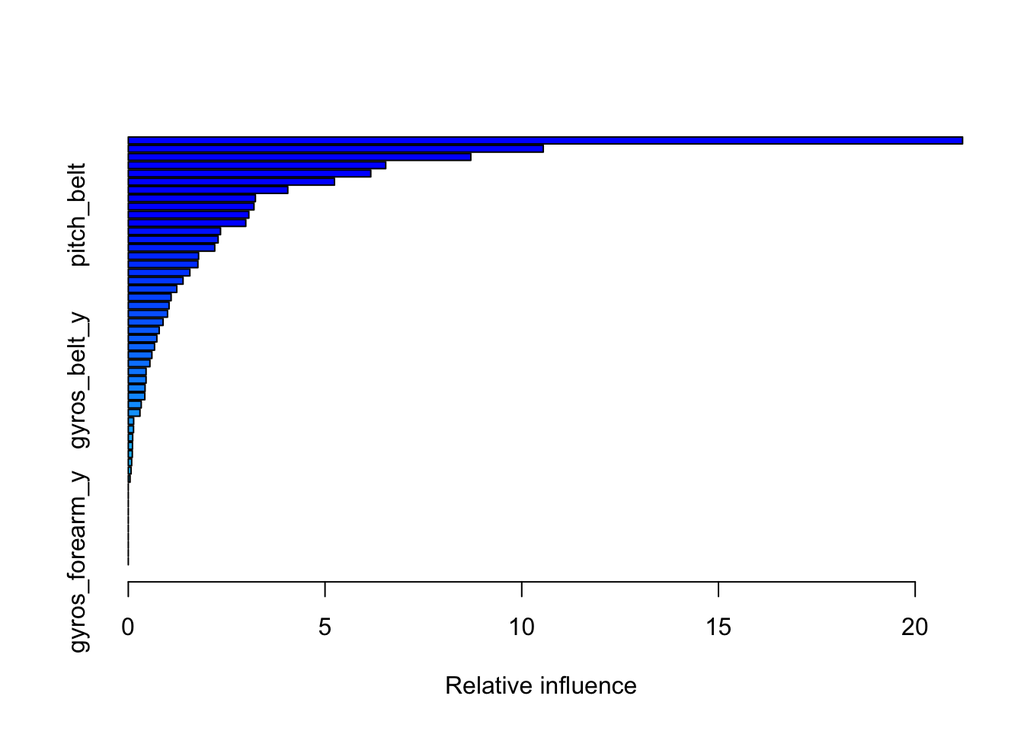

```
##                                       var  rel.inf
## roll_belt                       roll_belt 21.20405
## pitch_forearm               pitch_forearm 10.54708
## yaw_belt                         yaw_belt  8.70521
## magnet_dumbbell_z       magnet_dumbbell_z  6.54290
## magnet_dumbbell_y       magnet_dumbbell_y  6.16277
## roll_forearm                 roll_forearm  5.24004
## magnet_belt_z               magnet_belt_z  4.05347
## accel_forearm_x           accel_forearm_x  3.23072
## gyros_belt_z                 gyros_belt_z  3.19445
## pitch_belt                     pitch_belt  3.06363
## roll_dumbbell               roll_dumbbell  2.98609
## accel_dumbbell_y         accel_dumbbell_y  2.34390
## magnet_forearm_z         magnet_forearm_z  2.28316
## gyros_dumbbell_y         gyros_dumbbell_y  2.19724
## magnet_dumbbell_x       magnet_dumbbell_x  1.78629
## accel_dumbbell_x         accel_dumbbell_x  1.76887
## yaw_arm                           yaw_arm  1.56474
## accel_forearm_z           accel_forearm_z  1.39177
## magnet_belt_y               magnet_belt_y  1.23166
## roll_arm                         roll_arm  1.08897
## magnet_belt_x               magnet_belt_x  1.03635
## magnet_arm_z                 magnet_arm_z  0.99727
## accel_dumbbell_z         accel_dumbbell_z  0.88395
## magnet_arm_x                 magnet_arm_x  0.78552
## total_accel_dumbbell total_accel_dumbbell  0.72566
## accel_belt_z                 accel_belt_z  0.66698
## magnet_forearm_x         magnet_forearm_x  0.59984
## magnet_forearm_y         magnet_forearm_y  0.54972
## gyros_arm_y                   gyros_arm_y  0.45209
## gyros_belt_y                 gyros_belt_y  0.45206
## total_accel_forearm   total_accel_forearm  0.42627
## gyros_dumbbell_x         gyros_dumbbell_x  0.42000
## magnet_arm_y                 magnet_arm_y  0.32894
## accel_forearm_y           accel_forearm_y  0.29687
## accel_arm_x                   accel_arm_x  0.13634
## gyros_dumbbell_z         gyros_dumbbell_z  0.13305
## accel_arm_z                   accel_arm_z  0.11152
## total_accel_arm           total_accel_arm  0.10689
## accel_arm_y                   accel_arm_y  0.10232
## gyros_belt_x                 gyros_belt_x  0.08569
## gyros_forearm_z           gyros_forearm_z  0.07047
## gyros_arm_x                   gyros_arm_x  0.04519
## total_accel_belt         total_accel_belt  0.00000
## accel_belt_x                 accel_belt_x  0.00000
## accel_belt_y                 accel_belt_y  0.00000
## pitch_arm                       pitch_arm  0.00000
## gyros_arm_z                   gyros_arm_z  0.00000
## pitch_dumbbell             pitch_dumbbell  0.00000
## yaw_dumbbell                 yaw_dumbbell  0.00000
## yaw_forearm                   yaw_forearm  0.00000
## gyros_forearm_x           gyros_forearm_x  0.00000
## gyros_forearm_y           gyros_forearm_y  0.00000
```

```r
summary(modfit)
```

when looking inside the parameters, summary()showed us the relative influence (weighting) of the variables. We can see “roll_belt”" and “pitch_forearm” “yaw_belt” are the ones with most relative influence.

## Estimate on out of sample error

We estimate by calculating the accuracy of the model we got on the 10% data we intentionally left behind, with the accuracy calculated below.

```r
accuracy<-sum(predict(modfit,oos)==oos$classe)/length(oos$classe)
accuracy
```

```
## [1] 0.9613
```

## test the 20 testing cases

```r
predict(modfit,test)
```

```
##  [1] B A B A A E D B A A B C B A E E A B B B
## Levels: A B C D E
```

The result is generated by predict() command, which produced the results above. The prediction is correct (by submitting the answers I confirmed this.)